# 텍스트분석 뉴스레터: 2023년 3월

sung won kang

2023 5 16

- 한국환경연구원 텍스트 수집 도구는 2023년 5월 23일까지 네이버 기사 데이터와 환경부 문헌 데이터를 제공한다.아래 뉴스레터에서는 2023년 3월 31일을 기점으로 30일 이전까지 수집한 자료를 사용한다.

### A. Text 데이터

분석 대상 Text Data는 다음 두 종류의 문헌을 자료이다.

1. NAVER 환경 뉴스 : 2023년 3월 2일-2023년 3월 31일 NAVER 뉴스> ‘사회’ >‘환경’ 부문에 게시된 뉴스
2. 환경부 문건 : 2023년 3월 2일-2023년 3월 31일 환경부홈페이지에 게시된 환경부 보도자료 및 e-환경뉴스

’NAVER 환경 뉴스’는 환경정책의 수요자인 국민의 환경과 관련된 관심사를 전달하는 텍스트 자료이다. 그리고 ’환경부 문건’은 환경정책의 공급자인 환경부의 관심사를 전달하는 텍스트 자료이다. 이 두 자료의 키워드를 비교하여 환경정책 공급자의 관심사가 환경정책 수요자의 관심사에 조응하는지 여부를 점검한다.

### B. 키워드 빈도분석

한국환경연구원의 환경 빅데이터 플랫폼에서는 키워드를 단순빈도수 및 TF_IDF 값에 따라 추출한다. 키워드 추출 전단계로 파이선’konlpy’패키지를 활용한 형태소 분석 및 품사 태깅을 수행하고, 불용어(stopwords)를 제거한다. 2023년 3월 2일 - 3월 31일 게시 NAVER 환경뉴스 및 환경부 문건에서 단순빈도수가 높은 20개의 키워드를 추출한 결과는 아래 그림과 같다.

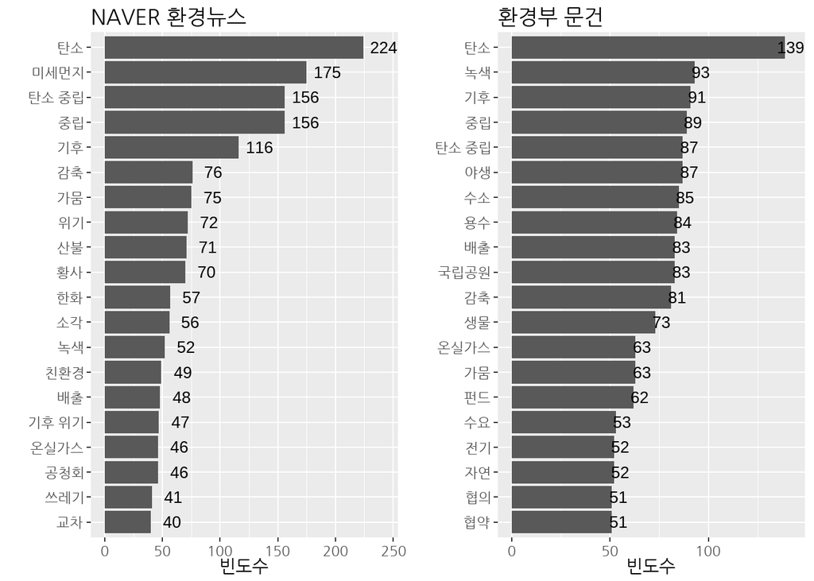

눈에 띄는 차이는 두 가지로 정리할 수 있다.

- 첫째, 네이버 환경뉴스에는 빈도수가 높은 상위 20개 키워드 중 ‘미세먼지’,‘황사’등 미세먼지 관련 키워드 및 ’소각’, ‘쓰레기’ 등 폐기물 관련 키워드가 발견되었지만 환경부 문건의 빈도수 상위 20개 키워드에는 이에 상응하는 키워드가 발견되지 않았다.
- 둘째, 환경부 문건의 빈도수 상위 20개 키워드 중에는’국립공원’,‘야생’,‘생물’,‘자연’ 등 자연환경 관련 키워드, 그리고 ‘수소’,‘용수’,‘전기’ 등의 키워드가 포함되지만 네이버 환경뉴스에서는 이에 상응하는 키워드가 발견되지 않았다.

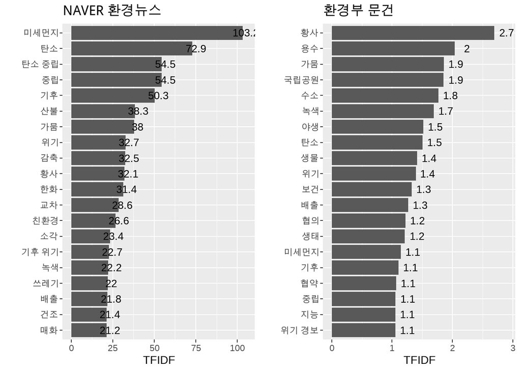

- “산불”,“감축”,“소각”,“쓰레기”,“건조” 와 같은 키워드는 NAVER 뉴스에서만 찾아볼 수 있고
- “용수”,“국립공원”,“수소”,“야생”,“생물”,“생태”와 같은 키워드들은 환경부 문건에서만 찾아 볼 수 있다.

### C. 키워드 관련 뉴스

네이버 환경뉴스 키워드와 환경부 문건 키워드간의 차이의 원인을 파악하기 위해서 두 문헌에서 단순빈도가 가장 높은 10개 키워드 중 서로 상이한 키워드가 포함된 문헌의 제목들을 비교하였다.

- 네이버 환경뉴스에서 단순빈도가 높은 10개 키워드 중 환경부 문건의 단순빈도가 높은 20개 키워드에 포함되지 않은 키워드는 [미세먼지, 위기, 산불, 황사]이다.
- 환경부 문헌에서 단순빈도가 높은 10개 키워드 중 네이버 환경뉴스에서 단순빈도가 높은 20개 키워드에 포함되지 않은 키워드는 [야생, 수소, 용수, 국립공원]이다.
1. ‘미세먼지’를 제목에 포함하는 기사들은 계절적으로 온도가 상승하면서 미세먼지 농도가 나빠지는 현상을 보도하는 기사들이다. 같은 기간 환경부 문헌 제목에 미세먼지를 포함하는 문헌은 2건(’미세먼지 간이측정기 측정 신뢰도 높인다’,’3월 20일 수도권(서울.인천.경기) 고농도 초미세먼지(PM2.5) 비상저감조치 시행) 에 그친다.

| Title |
| --- |
| ‘포근한 봄날’ 초미세먼지 주의보…뇌졸중까지 몰고 온다 |
| 개학 후 첫 주말, 낮 최고 17도 따뜻…전국 미세먼지 ‘나쁨’ |
| 금비·수도권대기환경청, 미세먼지 저감 협약 체결 |
| [내일날씨] 봄기운 ‘성큼’…곳곳 미세먼지 |
| [내일날씨] 낮 최고 17도…경기·대구·울산 미세먼지 ‘나쁨’ |
| [퇴근길날씨] 밤에도 영상권…경기·강원 미세먼지 ‘나쁨’ |
| 주말 아침엔 춥지만 낮 15도 내외 포근…산불·미세먼지 ‘주의’ |
| [날씨] 건조한 대기에 미세먼지 ‘나쁨’…큰 일교차 주의 |
| 아침 춥지만 낮 기온은 포근한 날씨…수도권 등 중부내륙은 미세먼지 나쁨 |
| [내일날씨] 기온 오르니 미세먼지 극성 |

2. ’위기’을 제목에 포함하는 기사들은 다양한 주제를 다루고 있었다. 제주 2공항 설립 후보지의 멸종위기종 관련 기사를 비롯한 멸종위기종 기사, 기후 위기 관련 기사, 일반적인 환경 위기 관련 기사 등 특정한 주제에 집중되어 있지 않았다.

| Title |
| --- |
| 제주2공항 부지서 저어새, 흑두루미 등 멸종위기종 다수 확인···“공항 강행은 학살” |
| 멸종위기 뿔쇠오리 위협 마라도 길고양이 3일 바지선으로 반출 |
| 환경 위기 속에서 ‘행동하는’ 우정과 협동의 중요성을 일깨우는 이야기 |
| 카카오뱅크, ‘기후위기 대응’ 타일러 라쉬 초청 강연 |
| [게시판] 카카오뱅크, 기후위기 주제로 타일러 라쉬 초청 강연 |
| 태국 북부 초미세먼지 위기 수준…“치앙마이 공기질 역대 최악” |
| ‘해양생태 보전’ 글로벌 조약 제정…“환경 위기에 공동 대응” |
| 유럽 환경규제 밀려든다…현지 韓기업 ‘위기를 기회로’ 활로모색 |
| 경주 형산강서 멸종위기 1급 수달 출몰… 최대 네 마리 활동 |
| 국립생태원, 제주 2공항 ‘검토 의견’ 제시…“멸종위기종 보호” |

3. ’산불’을 제목에 포함하는 기사들은 봄철 야외활동 증가 및 건조현상으로 인한 산불의 위험에 대한 기사가 대부분이었다. 같은 시기 ’산불’을 제목에 포함하는 환경부 문헌은 존재하지 않았다.

| Title |
| --- |
| 주말 아침엔 춥지만 낮 15도 내외 포근…산불·미세먼지 ‘주의’ |
| 울진 산불 1년, 천연기념물 산양은 잘 있을까 |
| 따뜻한 봄 날씨 등산객 ‘북적’…안전사고·산불 조심 |
| 나들이 가기 좋은 완연한 봄날…산불은 꼭 주의해주세요 |
| [이번주날씨] 낮 기온 최고 22도 ‘따뜻’…계속 건조 ‘산불 조심’ |
| “전년보다 산불 사고 2배”..전북소방본부 산불 예방 강화 |
| ‘산불 초비상’…산림청, 4월까지 산불방지에 사활 |
| “올해 임도 87.5㎞ 확충”···효율적 산림경영, 신속한 산불대응 목적[강원도] |
| 건조특보에 20㎧ 태풍급 강풍…대형산불 주의보 |
| 정부 “산불 방지 협조해달라…고의·과실엔 엄정 처벌” |

| Title |
| --- |
| 마스크 벗나 했더니 황사의 계절…“황사엔 보건용 마스크 써야” |
| 中 북방·서부, 돌풍 동반한 심한 황사…12개 성·시 경보 발령 |
| 중국발 황사 백령도 도착…서쪽지역 미세먼지 잠시 짙어질 수도 |
| 중국발 황사 서울서도 관측…중국 북동부 황사 추가 발원(종합) |
| 중국발 황사 서울서도 관측…중국 북동부 황사 추가 발원 |
| 중국발 황사 내려왔다..어제부터 미세먼지 농도 계속 ‘나쁨’ |
| 중국 북동부서도 황사 발원…내일 서해안 중심 영향 |
| 최악 中황사, 오늘 한반도 덮친다 “창문 닫아주세요” |
| 한총리, 경기·인천 황사경보에 “신속안내·안전조치에 최선” |
| 베이징 덮친 최악의 황사, 오늘 한반도 온다 |

환경부 문헌에서 가장 빈도가 높은 10개 키워드 중 네이버 뉴스에서 가장 빈도가 높은 키워드 20개에 포함되지 않은 키워드는 “야생”, “수소”, “용수”,“국립공원”이다. 2023년 3월 2일부터 3월 31일까지 게시된 환경부 문헌 중 이들 키워드를 제목에 포함하는 환경부 문헌은 다음과 같다.

1. ’야생’을 제목에 포함하는 문헌들은 야생조류 집단폐사 사건 조사 결과 문헌(2건)을 비롯한 생물종 보호 관련 문헌으로 파악되었다.

| Title |
| --- |
| 올겨울 야생조류 집단폐사 46건 중에 11건 농약중독 |
| 야생포유류 대상으로 조류인플루엔자 선제적 감시 |
| 야생조류 집단폐사 5건 중 3건에서 농약중독 확인 |
| 멸종위기 야생생물과의 동행…제3회 멸종위기종의 날 기념 |

2. ’수소’를 제목에 포함하는 문헌들은 수소차 보급 정책 관련 문헌으로 파악되었다.

| Title |
| --- |
| 수소 화물차 수요, 민관 손잡고 적극적으로 찾는다 |
| 현장 중심의 수소 상용차 보급 지원단 출범 |
| 수소 버스와 화물차 보급을 위해 민관이 힘을 합친다 |

3. ’용수’를 제목에 포함하는 문헌들은 봅철 가뭄대비 용수공급 대책 관련된 문헌으로 파악되었다.

| Title |
| --- |
| 농업용수 대체 공급, 섬진강댐 저수위 도달 약 1개월 지연 |
| 선제적 가뭄대책 이행…광주·전남 생공용수 차질없이 공급 |

4. ‘국립공원’ 관련 문헌은 국립공원 활용 촉진 관련 문헌이 2건, 해상해안국립공원의 생태휴식제 관련 문헌이 1건 이었다.

| Title |
| --- |
| 국립공원, 자연을 담고 사람을 품고 미래를 연다 |
| 해상해안국립공원, 갯바위 생태휴식제 확대한다 |
| 국립공원 친환경 숲속 결혼식의 주인공을 찾습니다 |

### D. 정리

2023년 3월 2일-2023년 3월 31일 게시된 네이버 환경뉴스와 환경부 문헌을 비교한 결과를 요약하면 다음과 같다.

1. 네이버 기사로부터 미세먼지, 황사 및 산불에 대한 국민들의 관심이 많은데 이와 관련된 환경부 문건의 비중은 낮은 것으로 파악되었다. 특히 미세먼지 및 황사 관련 환경부 문헌은 위기 경보의 발령 혹은 초미세먼지 대책 시행과 같이 정보 전달에 초점을 두고 있어서, 기존 대기오염 정책의 운영 관련된 정보에 집중되어 있다. 이는 미세먼지 및 황사 관련 정책이 개발 단계에서 운영 단계로 이행되었음을 시사한다.
2. 환경부 문헌으로부터 이 당시 환경부는 멸종위기종 보호, 수소차 보급, 가뭄 대비 용수공급, 국립공원 활용 증진을 추진하였음을 알 수 있다. 이 중 수소차 보급은 NAVER 뉴스에서 출현빈도가 높았던 ’기후’에 대한 관심에 조응하는 정책대응이라고 할 수 있다. 그러나 여타의 정책은 NAVER 뉴스의 관심을 얻지 못하였다.